# Sports Analytics SIG

#### Building a Logistic Regression Model to classify playoff teams

```r
library(ggplot2)

playoff.lr <- glm(Playoff ~ FT, family = "binomial", data = num.data)
summary(playoff.lr)
```

```
##
## Call:
## glm(formula = Playoff ~ FT, family = "binomial", data = num.data)
##
## Deviance Residuals:
##     Min       1Q   Median       3Q      Max
## -1.6748  -1.1874   0.8286   1.1089   1.4856
##
## Coefficients:
##             Estimate Std. Error z value Pr(>|z|)
## (Intercept) -3.49356    1.17573  -2.971  0.00296 **
## FT           0.20689    0.06686   3.094  0.00197 **
## ---
## Signif. codes:  0 '***' 0.001 '**' 0.01 '*' 0.05 '.' 0.1 ' ' 1
##
## (Dispersion parameter for binomial family taken to be 1)
##
##     Null deviance: 414.55  on 299  degrees of freedom
## Residual deviance: 404.34  on 298  degrees of freedom
## AIC: 408.34
##
## Number of Fisher Scoring iterations: 4
```

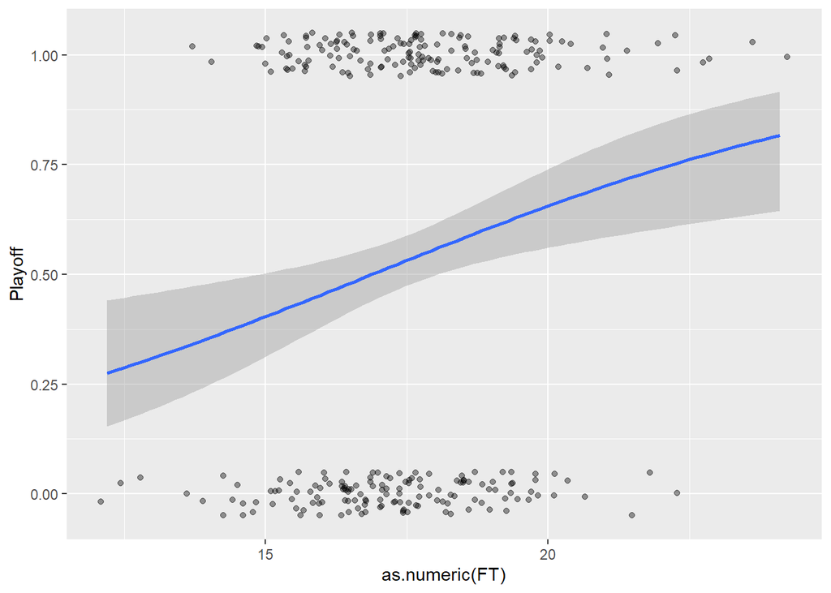

```r
playoff.lr.plot <- ggplot(data = num.data, aes(x =
                                              as.numeric(FT),
                                              y = Playoff)) +
  geom_jitter(height = 0.05, width = 0.3, alpha=0.4) +
  geom_smooth(method = "glm", method.args = list(family = "binomial"))
playoff.lr.plot
```

#### Building a Tree to classify playoff teams

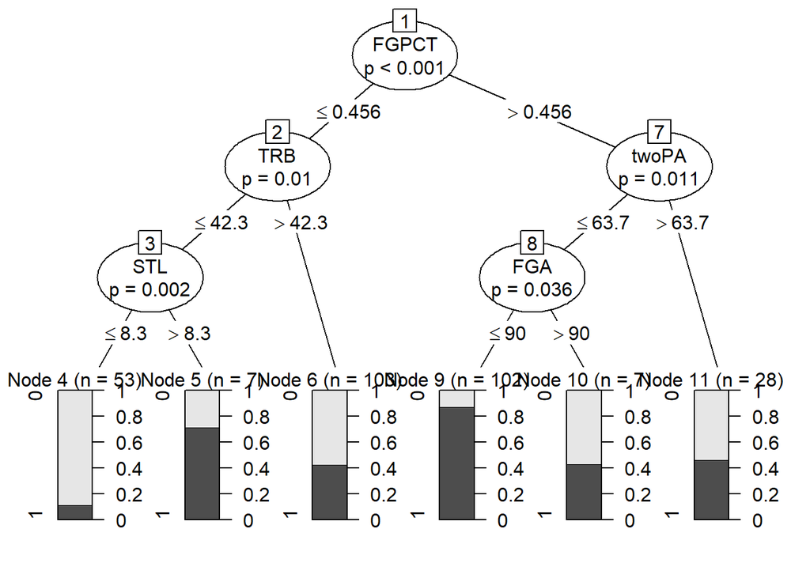

```r
library(party)

playoff.tree <- ctree(as.factor(Playoff) ~ ., num.data)
plot(playoff.tree)
```

#### Building a Random Forest to classify playoff teams

```r
library(tidyverse)
library(randomForest)

playoff.forest <- randomForest(as.factor(Playoff) ~ ., num.data)
table(num.data$Playoff, predict(playoff.forest, num.data))
```

```
##
##       0   1
##   0 140   0
##   1   0 160
```

#### Building a Support Vector Machine to classify playoff teams

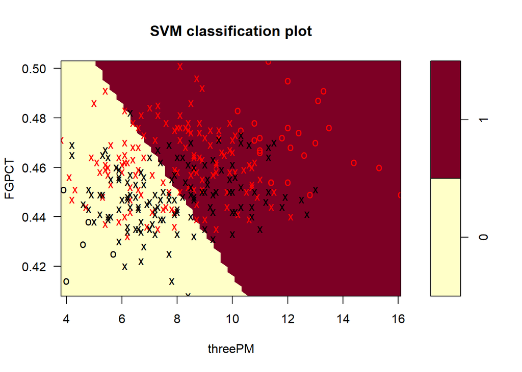

```r
library(e1071)

svm.data <- select(num.data, Playoff, FGPCT, threePM) %>% filter()
playoff.svm = svm(as.factor(Playoff) ∼., svm.data, kernel ="linear", cost=10,
scale=FALSE)
plot(playoff.svm, svm.data)
```

```r
summary(playoff.svm)
```

```
##
## Call:
## svm(formula = as.factor(Playoff) ~ ., data = svm.data, kernel = "linear",
##     cost = 10, scale = FALSE)
##
##
## Parameters:
##    SVM-Type:  C-classification
##  SVM-Kernel:  linear
##        cost:  10
##
## Number of Support Vectors:  270
##
##  ( 135 135 )
##
##
## Number of Classes:  2
##
## Levels:
##  0 1
```

> **Textbooks for Reference**
1. Ulf Brefeld, Jesse Davis, Jan Van Haaren, Albrecht Zimmermann.: Machine Learning and Data Mining for Sports Analytics. *Springer*, https://link-springer-com.proxy.lib.uiowa.edu/book/10.1007/978-3-030-17274-9#editorsandaffiliations
2. Gareth James, Daniela Witten, Trevor Hastie, Robert Tibshirani.: An Introduction to Statistical Learning. *Springer*, https://link-springer-com.proxy.lib.uiowa.edu/book/10.1007/978-1-4614-7138-7#about
3. Gareth James, Daniela Witten, Trevor Hastie, Robert Tibshirani.: An Introduction to Statistical Learning. *Springer*, https://link-springer-com.proxy.lib.uiowa.edu/book/10.1007/978-1-4614-7138-7#about
4. Tom Barker.: Pro Data Visualization using R and JavaScript. *Springer*, https://link-springer-com.proxy.lib.uiowa.edu/book/10.1007/978-1-4302-5807-0
5. Ossama Embarak.: Data Analysis and Visualization Using Python. *Springer*, https://link-springer-com.proxy.lib.uiowa.edu/book/10.1007/978-1-4842-4109-7